# HDS M7 assessment: alcohol intake and incident cardiovascular disease (Framingham)

Reproducible analysis code (R Markdown)

19 November 2026

**Source code repository:** https://github.com/ibrahimalfawaz/Cambridge-Module-7.git

To reproduce every table, figure and number in the report:

```bash
git clone https://github.com/ibrahimalfawaz/Cambridge-Module-7.git
cd Cambridge-Module-7
Rscript -e 'rmarkdown::render("HDS_M7_IBRAHIM_2611.Rmd")'
```

The data file `framingham_heart_study.csv` must sit in the same folder as this `.Rmd`. All paths are relative, the random seed is fixed, and outputs are written to `outputs/`.

# 1 Set-up

## 1.1 Packages

All packages are on CRAN. The chunk stops with a clear message if any is missing, rather than installing silently.

```r
pkgs <- c("survival",  # Cox models, cox.zph, Kaplan-Meier
          "splines",   # natural cubic splines (base R)
          "mice",      # multiple imputation (sensitivity analysis)
          "dplyr", "tidyr",
          "ggplot2", "patchwork")
missing_pkgs <- pkgs[!vapply(pkgs, requireNamespace, logical(1), quietly = TRUE)]
if (length(missing_pkgs) > 0) {
  stop("Please install: install.packages(c(", paste0('"', missing_pkgs, '"', collapse = ", "), "))")
}
invisible(lapply(pkgs, library, character.only = TRUE))
set.seed(20261101)        # reproducible imputation and bootstrap
dir.create("outputs", showWarnings = FALSE)
sessionInfo()$R.version$version.string
```

```
## [1] "R version 4.3.3 (2024-02-29)"
```

## 1.2 Helper functions

```r
# HR (95% CI) for a named coefficient of a coxph fit
hr_ci <- function(fit, term) {
  b  <- unname(coef(fit)[term]); se <- unname(sqrt(diag(vcov(fit)))[term])
  c(HR = exp(b), lo = exp(b - 1.96 * se), hi = exp(b + 1.96 * se),
    p = 2 * pnorm(-abs(b / se)))
}
fmt_hr <- function(x) sprintf("%.2f (%.2f-%.2f)", x[1], x[2], x[3])
fmt_p  <- function(p) ifelse(p < 0.001, "<0.001", sprintf("%.3f", p))
```

# 2 Data preparation

## 2.1 Read data and construct the analysis cohort

The file has one row per participant per examination. Outcome indicators/times are measured from the baseline examination and are identical across a participant’s rows, and alcohol (`ALC_DPW`) was measured once at baseline. The analysis is therefore a **baseline cohort**: one row per participant (`PERIOD == 1`).

Participants with prevalent coronary heart disease (`PREVCHD`, which includes prevalent angina and MI) or prevalent stroke (`PREVSTRK`) at baseline are excluded, because they are not at risk of a *first* CVD event and their drinking may already have changed because of their illness (reverse causation).

```r
raw <- read.csv("framingham_heart_study.csv")

# --- data checks ---
stopifnot(nrow(raw) == 11627, length(unique(raw$RANDID)) == 4434)
stopifnot(all(table(raw$RANDID[raw$PERIOD == 1]) == 1))      # one baseline row each
# alcohol is constant within participant (measured once at baseline)
stopifnot(all(tapply(raw$ALC_DPW, raw$RANDID, function(x) length(unique(x))) == 1))

base <- subset(raw, PERIOD == 1)
flow <- data.frame(step = c("Baseline examination", "Excluded: prevalent CHD or stroke"),
                   n    = c(nrow(base), sum(base$PREVCHD == 1 | base$PREVSTRK == 1)))
d <- subset(base, PREVCHD == 0 & PREVSTRK == 0)
flow <- rbind(flow, data.frame(step = "Analysis cohort", n = nrow(d)))
flow
```

```
##                                step    n
## 1              Baseline examination 4434
## 2 Excluded: prevalent CHD or stroke  219
## 3                   Analysis cohort 4215
```

## 2.2 Derive variables

- **Exposure.** `ALC_DPW` (standard drinks/week). Used (i) in five categories that map onto common guideline thresholds - non-drinker (0), >0-7, >7-14, >14-21 and >21 drinks/week - with non-drinkers as reference; (ii) continuously, scaled per 7 drinks/week (≈1 drink/day); (iii) as a natural cubic spline.
- **Outcomes.** Total CVD (primary), and the subtypes any CHD, hospitalised MI or fatal CHD, angina pectoris and stroke. Time in years from baseline.
- **Confounders** (chosen a priori from a causal diagram, not by statistical selection): age, sex, education and smoking (current smoker + cigarettes/day). These affect drinking and CVD risk and are not plausibly caused by drinking.

```r
d <- d |>
  mutate(
    sex      = factor(SEX, levels = 1:2, labels = c("Men", "Women")),
    educ_f   = factor(educ, levels = 1:4,
                      labels = c("0-11 years", "High school/GED", "Some college", "College degree")),
    alc_cat  = cut(ALC_DPW, breaks = c(-Inf, 0, 7, 14, 21, Inf),
                   labels = c("Non-drinker", ">0-7", ">7-14", ">14-21", ">21")),
    alc7     = ALC_DPW / 7,                       # per 7 drinks/week
    drinker  = as.integer(ALC_DPW > 0),
    cursmoke = CURSMOKE,
    cigpday  = CIGPDAY,
    # outcomes: time in years
    t_cvd = TIMECVD / 365.25,  e_cvd = CVD,
    t_chd = TIMECHD / 365.25,  e_chd = ANYCHD,
    t_mif = TIMEMIFC / 365.25, e_mif = MI_FCHD,
    t_ap  = TIMEAP / 365.25,   e_ap  = ANGINA,
    t_str = TIMESTRK / 365.25, e_str = STROKE,
    t_dth = TIMEDTH / 365.25,  e_dth = DEATH
  )

outcomes <- data.frame(
  key   = c("cvd", "chd", "mif", "ap", "str"),
  label = c("Total CVD", "Any CHD", "MI or fatal CHD", "Angina pectoris", "Stroke"))

# plausibility checks
stopifnot(all(d$t_cvd > 0), all(d$ALC_DPW >= 0))
summary(d$ALC_DPW)
```

```
##    Min. 1st Qu.  Median    Mean 3rd Qu.    Max.
##   0.000   0.000   6.300   9.121  13.100 132.300
```

```r
table(d$alc_cat)
```

```
##
## Non-drinker        >0-7       >7-14      >14-21         >21
##        1286         996         997         487         449
```

Within-category medians are used to test for linear trend across categories.

```r
cat_medians <- tapply(d$ALC_DPW, d$alc_cat, median)
d$alc_cat_med <- cat_medians[as.character(d$alc_cat)] / 7   # per 7 drinks/week
round(cat_medians, 1)
```

```
## Non-drinker        >0-7       >7-14      >14-21         >21
##         0.0         5.0         9.9        17.3        28.4
```

## 2.3 Missing data

```r
vars_needed <- c("AGE", "sex", "educ_f", "cursmoke", "cigpday", "ALC_DPW",
                 "BMI", "TOTCHOL", "SYSBP", "DIABETES", "BPMEDS", "GLUCOSE", "HEARTRTE")
miss <- data.frame(variable = vars_needed,
                   n_missing = sapply(d[vars_needed], function(x) sum(is.na(x))))
miss$pct <- round(100 * miss$n_missing / nrow(d), 1)
miss
```

```
##          variable n_missing pct
## AGE           AGE         0 0.0
## sex           sex         0 0.0
## educ_f     educ_f       105 2.5
## cursmoke cursmoke         0 0.0
## cigpday   cigpday        29 0.7
## ALC_DPW   ALC_DPW         0 0.0
## BMI           BMI        17 0.4
## TOTCHOL   TOTCHOL        50 1.2
## SYSBP       SYSBP         0 0.0
## DIABETES DIABETES         0 0.0
## BPMEDS     BPMEDS        52 1.2
## GLUCOSE   GLUCOSE       387 9.2
## HEARTRTE HEARTRTE         1 0.0
```

```r
conf_vars <- c("AGE", "sex", "educ_f", "cursmoke", "cigpday")
d$cc <- complete.cases(d[, c(conf_vars, "ALC_DPW")])
table(complete_case = d$cc)
```

```
## complete_case
## FALSE  TRUE
##   132  4083
```

```r
# Is missingness related to exposure or outcome? (informs the MAR/CCA judgement)
round(prop.table(table(d$cc, d$e_cvd), 1), 3)
```

```
##
##             0     1
##   FALSE 0.727 0.273
##   TRUE  0.765 0.235
```

```r
summary(glm(!cc ~ ALC_DPW + AGE + sex + e_cvd, data = d, family = binomial))$coef
```

```
##                  Estimate  Std. Error      z value     Pr(>|z|)
## (Intercept) -3.794109e+00 0.552728386 -6.864328105 6.680493e-12
## ALC_DPW      3.305125e-05 0.008253124  0.004004696 9.968047e-01
## AGE          9.791464e-03 0.010575960  0.925822681 3.545381e-01
## sexWomen    -2.833582e-01 0.191564939 -1.479175472 1.390934e-01
## e_cvd        1.003157e-01 0.207837189  0.482664637 6.293339e-01
```

```r
dc <- subset(d, cc)
nrow(dc)
```

```
## [1] 4083
```

# 3 Descriptive statistics (Table 1)

```r
mean_sd <- function(x) sprintf("%.1f (%.1f)", mean(x, na.rm = TRUE), sd(x, na.rm = TRUE))
med_iqr <- function(x) { q <- quantile(x, c(.5, .25, .75), na.rm = TRUE)
                          sprintf("%.1f (%.1f-%.1f)", q[1], q[2], q[3]) }
n_pct   <- function(x) sprintf("%d (%.1f)", sum(x, na.rm = TRUE), 100 * mean(x, na.rm = TRUE))

desc_col <- function(g) c(
  "N"                              = format(nrow(g), big.mark = ","),
  "Alcohol, drinks/week"           = med_iqr(g$ALC_DPW),
  "Age, years"                     = mean_sd(g$AGE),
  "Women, n (%)"                   = n_pct(g$sex == "Women"),
  "College degree, n (%)"          = n_pct(g$educ == 4),
  "Current smoker, n (%)"          = n_pct(g$cursmoke == 1),
  "Cigarettes/day (smokers)"       = mean_sd(g$cigpday[g$cursmoke == 1]),
  "BMI, kg/m2"                     = mean_sd(g$BMI),
  "Systolic BP, mmHg"              = mean_sd(g$SYSBP),
  "Total cholesterol, mg/dL"       = mean_sd(g$TOTCHOL),
  "Diabetes, n (%)"                = n_pct(g$DIABETES == 1),
  "Antihypertensive use, n (%)"    = n_pct(g$BPMEDS == 1),
  "Follow-up, years"               = med_iqr(g$t_cvd),
  "Incident CVD, n (%)"            = n_pct(g$e_cvd == 1))

table1 <- data.frame(Characteristic = names(desc_col(d)),
                     sapply(split(d, d$alc_cat), desc_col),
                     Overall = desc_col(d), check.names = FALSE, row.names = NULL)
knitr::kable(table1)
```

| Characteristic | Non-drinker | >0-7 | >7-14 | >14-21 | >21 | Overall |
| --- | --- | --- | --- | --- | --- | --- |
| N | 1,286 | 996 | 997 | 487 | 449 | 4,215 |
| Alcohol, drinks/week | 0.0 (0.0-0.0) | 5.0 (4.0-6.0) | 9.9 (8.5-11.8) | 17.3 (15.7-18.9) | 28.4 (24.1-37.1) | 6.3 (0.0-13.1) |
| Age, years | 50.8 (8.6) | 49.5 (8.6) | 49.0 (8.4) | 48.9 (8.4) | 47.9 (8.4) | 49.5 (8.6) |
| Women, n (%) | 1017 (79.1) | 638 (64.1) | 479 (48.0) | 160 (32.9) | 111 (24.7) | 2405 (57.1) |
| College degree, n (%) | 132 (10.5) | 112 (11.6) | 107 (11.1) | 57 (11.9) | 65 (15.0) | 473 (11.5) |
| Current smoker, n (%) | 451 (35.1) | 446 (44.8) | 549 (55.1) | 316 (64.9) | 326 (72.6) | 2088 (49.5) |
| Cigarettes/day (smokers) | 17.2 (10.4) | 16.4 (10.3) | 18.1 (10.6) | 21.1 (11.4) | 20.7 (11.3) | 18.4 (10.9) |
| BMI, kg/m2 | 25.8 (4.3) | 25.7 (4.1) | 25.8 (4.0) | 26.1 (3.9) | 25.8 (3.8) | 25.8 (4.1) |
| Systolic BP, mmHg | 134.2 (23.7) | 131.1 (21.0) | 132.5 (22.4) | 130.5 (19.8) | 130.8 (20.0) | 132.3 (22.0) |
| Total cholesterol, mg/dL | 238.6 (44.3) | 236.7 (44.2) | 236.2 (44.5) | 235.7 (44.3) | 233.4 (46.7) | 236.7 (44.6) |
| Diabetes, n (%) | 34 (2.6) | 27 (2.7) | 30 (3.0) | 9 (1.8) | 8 (1.8) | 108 (2.6) |
| Antihypertensive use, n (%) | 46 (3.6) | 30 (3.0) | 25 (2.5) | 11 (2.3) | 5 (1.1) | 117 (2.8) |
| Follow-up, years | 24.0 (15.7-24.0) | 24.0 (15.7-24.0) | 24.0 (15.3-24.0) | 24.0 (14.4-24.0) | 24.0 (15.2-24.0) | 24.0 (15.4-24.0) |
| Incident CVD, n (%) | 306 (23.8) | 221 (22.2) | 237 (23.8) | 129 (26.5) | 103 (22.9) | 996 (23.6) |

```r
write.csv(table1, "outputs/table1_baseline.csv", row.names = FALSE)
```

# 4 Primary analysis: Cox proportional hazards models (Table 2)

Cox regression is used because the outcomes are times to first event with right censoring (end of follow-up, death, loss to follow-up). Each subtype is analysed with its own event time; deaths from other causes are censored, so the hazard ratios (HRs) are **cause-specific** HRs, appropriate for an aetiological question. Two models are fitted per outcome: Model 1 (age and sex) and Model 2 (+ education and smoking, the primary model).

```r
adj1 <- "AGE + sex"
adj2 <- "AGE + sex + educ_f + cursmoke + cigpday"

fit_cox <- function(outc, rhs, data = dc) {
  f <- as.formula(paste0("Surv(t_", outc, ", e_", outc, ") ~ ", rhs))
  coxph(f, data = data)
}

rows <- list(); fits_cat <- list(); fits_lin <- list()
for (i in seq_len(nrow(outcomes))) {
  k  <- outcomes$key[i]
  m0 <- fit_cox(k, "alc_cat")                         # unadjusted
  m1 <- fit_cox(k, paste("alc_cat +", adj1))
  m2 <- fit_cox(k, paste("alc_cat +", adj2))
  tr <- fit_cox(k, paste("alc_cat_med +", adj2))       # trend across categories
  li <- fit_cox(k, paste("alc7 +", adj2))              # per 7 drinks/week
  fits_cat[[k]] <- m2; fits_lin[[k]] <- li
  ev <- tapply(dc[[paste0("e_", k)]], dc$alc_cat, sum)
  py <- tapply(dc[[paste0("t_", k)]], dc$alc_cat, sum)
  for (j in levels(dc$alc_cat)) {
    term <- paste0("alc_cat", j)
    rows[[length(rows) + 1]] <- data.frame(
      outcome = outcomes$label[i], category = j, events = ev[j],
      rate_1000py = round(1000 * ev[j] / py[j], 1),
      HR_crude  = if (j == "Non-drinker") "1.00 (ref)" else fmt_hr(hr_ci(m0, term)),
      HR_model1 = if (j == "Non-drinker") "1.00 (ref)" else fmt_hr(hr_ci(m1, term)),
      HR_model2 = if (j == "Non-drinker") "1.00 (ref)" else fmt_hr(hr_ci(m2, term)))
  }
  rows[[length(rows) + 1]] <- data.frame(
    outcome = outcomes$label[i], category = "Per 7 drinks/week",
    events = sum(ev), rate_1000py = round(1000 * sum(ev) / sum(py), 1),
    HR_crude  = fmt_hr(hr_ci(fit_cox(k, "alc7"), "alc7")),
    HR_model1 = fmt_hr(hr_ci(fit_cox(k, paste("alc7 +", adj1)), "alc7")),
    HR_model2 = fmt_hr(hr_ci(li, "alc7")))
  rows[[length(rows) + 1]] <- data.frame(
    outcome = outcomes$label[i], category = "P for trend", events = NA, rate_1000py = NA,
    HR_crude  = fmt_p(hr_ci(fit_cox(k, "alc_cat_med"), "alc_cat_med")["p"]),
    HR_model1 = fmt_p(hr_ci(fit_cox(k, paste("alc_cat_med +", adj1)), "alc_cat_med")["p"]),
    HR_model2 = fmt_p(hr_ci(tr, "alc_cat_med")["p"]))
}
table2 <- do.call(rbind, rows); rownames(table2) <- NULL
knitr::kable(table2)
```

| outcome | category | events | rate_1000py | HR_crude | HR_model1 | HR_model2 |
| --- | --- | --- | --- | --- | --- | --- |
| Total CVD | Non-drinker | 298 | 12.2 | 1.00 (ref) | 1.00 (ref) | 1.00 (ref) |
| Total CVD | >0-7 | 218 | 11.4 | 0.93 (0.79-1.11) | 0.89 (0.75-1.06) | 0.88 (0.73-1.05) |
| Total CVD | >7-14 | 224 | 12.2 | 1.00 (0.84-1.19) | 0.88 (0.73-1.05) | 0.85 (0.71-1.01) |
| Total CVD | >14-21 | 125 | 13.9 | 1.14 (0.93-1.41) | 0.89 (0.71-1.11) | 0.82 (0.66-1.03) |
| Total CVD | >21 | 95 | 11.5 | 0.95 (0.75-1.20) | 0.73 (0.57-0.92) | 0.67 (0.52-0.85) |
| Total CVD | Per 7 drinks/week | 960 | 12.1 | 0.99 (0.96-1.04) | 0.94 (0.90-0.99) | 0.92 (0.88-0.97) |
| Total CVD | P for trend | NA | NA | 0.745 | 0.017 | 0.001 |
| Any CHD | Non-drinker | 317 | 13.2 | 1.00 (ref) | 1.00 (ref) | 1.00 (ref) |
| Any CHD | >0-7 | 228 | 12.2 | 0.92 (0.78-1.09) | 0.87 (0.73-1.03) | 0.87 (0.73-1.03) |
| Any CHD | >7-14 | 231 | 12.7 | 0.96 (0.81-1.14) | 0.83 (0.69-0.99) | 0.82 (0.68-0.98) |
| Any CHD | >14-21 | 122 | 13.6 | 1.03 (0.84-1.27) | 0.81 (0.65-1.01) | 0.78 (0.62-0.97) |
| Any CHD | >21 | 102 | 12.5 | 0.95 (0.76-1.19) | 0.72 (0.57-0.91) | 0.68 (0.54-0.87) |
| Any CHD | Per 7 drinks/week | 1000 | 12.8 | 0.99 (0.96-1.03) | 0.94 (0.90-0.98) | 0.93 (0.89-0.97) |
| Any CHD | P for trend | NA | NA | 0.948 | 0.006 | 0.001 |
| MI or fatal CHD | Non-drinker | 169 | 6.6 | 1.00 (ref) | 1.00 (ref) | 1.00 (ref) |
| MI or fatal CHD | >0-7 | 125 | 6.3 | 0.95 (0.75-1.20) | 0.83 (0.66-1.05) | 0.83 (0.65-1.04) |
| MI or fatal CHD | >7-14 | 150 | 7.9 | 1.19 (0.96-1.49) | 0.92 (0.73-1.15) | 0.89 (0.71-1.12) |
| MI or fatal CHD | >14-21 | 74 | 7.8 | 1.19 (0.91-1.57) | 0.80 (0.60-1.06) | 0.74 (0.55-0.98) |
| MI or fatal CHD | >21 | 63 | 7.4 | 1.12 (0.84-1.49) | 0.70 (0.52-0.95) | 0.64 (0.47-0.87) |
| MI or fatal CHD | Per 7 drinks/week | 581 | 7.0 | 1.03 (0.98-1.08) | 0.95 (0.90-1.00) | 0.93 (0.88-0.98) |
| MI or fatal CHD | P for trend | NA | NA | 0.155 | 0.029 | 0.004 |
| Angina pectoris | Non-drinker | 165 | 6.7 | 1.00 (ref) | 1.00 (ref) | 1.00 (ref) |
| Angina pectoris | >0-7 | 128 | 6.6 | 0.99 (0.79-1.25) | 0.98 (0.77-1.23) | 0.99 (0.78-1.24) |
| Angina pectoris | >7-14 | 126 | 6.7 | 1.01 (0.80-1.27) | 0.95 (0.75-1.21) | 0.96 (0.75-1.22) |
| Angina pectoris | >14-21 | 62 | 6.7 | 1.01 (0.76-1.36) | 0.91 (0.67-1.24) | 0.92 (0.67-1.25) |
| Angina pectoris | >21 | 59 | 7.0 | 1.06 (0.79-1.42) | 0.94 (0.69-1.30) | 0.94 (0.69-1.30) |
| Angina pectoris | Per 7 drinks/week | 540 | 6.7 | 0.99 (0.94-1.05) | 0.97 (0.91-1.03) | 0.97 (0.91-1.03) |
| Angina pectoris | P for trend | NA | NA | 0.711 | 0.618 | 0.620 |
| Stroke | Non-drinker | 106 | 4.1 | 1.00 (ref) | 1.00 (ref) | 1.00 (ref) |
| Stroke | >0-7 | 81 | 4.0 | 0.97 (0.73-1.30) | 1.05 (0.79-1.41) | 1.04 (0.77-1.39) |
| Stroke | >7-14 | 74 | 3.8 | 0.92 (0.68-1.24) | 1.05 (0.77-1.43) | 1.00 (0.74-1.37) |
| Stroke | >14-21 | 46 | 4.8 | 1.17 (0.82-1.65) | 1.27 (0.88-1.83) | 1.16 (0.80-1.68) |
| Stroke | >21 | 35 | 4.0 | 0.98 (0.67-1.44) | 1.15 (0.76-1.72) | 1.05 (0.69-1.58) |
| Stroke | Per 7 drinks/week | 342 | 4.1 | 0.99 (0.92-1.06) | 1.02 (0.95-1.10) | 1.00 (0.93-1.08) |
| Stroke | P for trend | NA | NA | 0.782 | 0.316 | 0.670 |

```r
write.csv(table2, "outputs/table2_cox.csv", row.names = FALSE)
summary(fits_cat$cvd)
```

```
## Call:
## coxph(formula = f, data = data)
##
##   n= 4083, number of events= 960
##
##                            coef exp(coef)  se(coef)       z Pr(>|z|)
## alc_cat>0-7           -0.131304  0.876951  0.090379  -1.453  0.14628
## alc_cat>7-14          -0.167405  0.845857  0.092498  -1.810  0.07032 .
## alc_cat>14-21         -0.195500  0.822423  0.112691  -1.735  0.08277 .
## alc_cat>21            -0.405573  0.666595  0.125206  -3.239  0.00120 **
## AGE                    0.070248  1.072775  0.004102  17.123  < 2e-16 ***
## sexWomen              -0.794230  0.451929  0.073775 -10.766  < 2e-16 ***
## educ_fHigh school/GED -0.038553  0.962181  0.078701  -0.490  0.62423
## educ_fSome college    -0.288594  0.749316  0.102896  -2.805  0.00504 **
## educ_fCollege degree  -0.183107  0.832679  0.109753  -1.668  0.09525 .
## cursmoke               0.193555  1.213556  0.100965   1.917  0.05523 .
## cigpday                0.006282  1.006302  0.004098   1.533  0.12523
## ---
## Signif. codes:  0 '***' 0.001 '**' 0.01 '*' 0.05 '.' 0.1 ' ' 1
##
##                       exp(coef) exp(-coef) lower .95 upper .95
## alc_cat>0-7              0.8770     1.1403    0.7346    1.0469
## alc_cat>7-14             0.8459     1.1822    0.7056    1.0140
## alc_cat>14-21            0.8224     1.2159    0.6594    1.0257
## alc_cat>21               0.6666     1.5002    0.5215    0.8520
## AGE                      1.0728     0.9322    1.0642    1.0814
## sexWomen                 0.4519     2.2127    0.3911    0.5222
## educ_fHigh school/GED    0.9622     1.0393    0.8246    1.1227
## educ_fSome college       0.7493     1.3346    0.6125    0.9167
## educ_fCollege degree     0.8327     1.2009    0.6715    1.0325
## cursmoke                 1.2136     0.8240    0.9957    1.4791
## cigpday                  1.0063     0.9937    0.9983    1.0144
##
## Concordance= 0.704  (se = 0.008 )
## Likelihood ratio test= 485.6  on 11 df,   p=<2e-16
## Wald test            = 476.2  on 11 df,   p=<2e-16
## Score (logrank) test = 500.1  on 11 df,   p=<2e-16
```

## 4.1 Global test of the categorical exposure

```r
# likelihood-ratio test: does alcohol (5 categories) improve the primary CVD model?
anova(fit_cox("cvd", adj2), fits_cat$cvd)
```

```
## Analysis of Deviance Table
##  Cox model: response is  Surv(t_cvd, e_cvd)
##  Model 1: ~ AGE + sex + educ_f + cursmoke + cigpday
##  Model 2: ~ alc_cat + AGE + sex + educ_f + cursmoke + cigpday
##    loglik  Chisq Df Pr(>|Chi|)
## 1 -7517.0
## 2 -7511.3 11.387  4    0.02254 *
## ---
## Signif. codes:  0 '***' 0.001 '**' 0.01 '*' 0.05 '.' 0.1 ' ' 1
```

## 4.2 Checking the proportional hazards assumption

Schoenfeld-residual (Grambsch-Therneau) tests for every outcome, and a plot for the primary model.

```r
ph <- lapply(outcomes$key, function(k) cox.zph(fits_lin[[k]]))
names(ph) <- outcomes$label
ph_tab <- t(sapply(ph, function(z) c(alcohol_p = z$table["alc7", "p"], global_p = z$table["GLOBAL", "p"])))
round(ph_tab, 3)
```

```
##                 alcohol_p global_p
## Total CVD           0.227    0.042
## Any CHD             0.758    0.000
## MI or fatal CHD     0.356    0.042
## Angina pectoris     0.948    0.000
## Stroke              0.890    0.552
```

```r
cox.zph(fits_cat$cvd)
```

```
##            chisq df      p
## alc_cat   9.3107  4 0.0538
## AGE       0.3540  1 0.5519
## sex       0.1281  1 0.7204
## educ_f    4.7562  3 0.1905
## cursmoke  0.0549  1 0.8147
## cigpday   3.2816  1 0.0701
## GLOBAL   26.0527 11 0.0064
```

```r
# which covariates drive the global PH violations for CHD and angina?
cox.zph(fits_lin$chd); cox.zph(fits_lin$ap)
```

```
##            chisq df       p
## alc7      0.0947  1 0.75833
## AGE      15.1243  1 0.00010
## sex       0.0853  1 0.77021
## educ_f    3.1952  3 0.36250
## cursmoke  0.4046  1 0.52471
## cigpday   4.1758  1 0.04100
## GLOBAL   28.6371  8 0.00037
```

```
##            chisq df       p
## alc7      0.0043  1   0.948
## AGE      42.1241  1 8.6e-11
## sex       0.1209  1   0.728
## educ_f    2.5537  3   0.466
## cursmoke  0.2171  1   0.641
## cigpday   5.0316  1   0.025
## GLOBAL   58.4872  8 9.2e-10
```

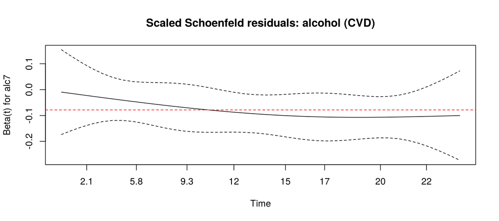

```r
plot(cox.zph(fits_lin$cvd)[1], resid = FALSE, main = "Scaled Schoenfeld residuals: alcohol (CVD)")
abline(h = coef(fits_lin$cvd)["alc7"], lty = 2, col = "red")
```

The alcohol term satisfies PH for every outcome. Age violates PH for CHD and angina (its effect changes over follow-up). Remedy: stratify the baseline hazard by 5-year age bands, so age-specific baseline hazards can take any shape over time while the alcohol HR is still estimated.

```r
dc$age_band <- cut(dc$AGE, breaks = c(-Inf, 39, 44, 49, 54, 59, Inf))
ph_strat <- t(sapply(outcomes$key, function(k) {
  fs <- fit_cox(k, "alc7 + strata(age_band) + sex + educ_f + cursmoke + cigpday")
  c(primary = fmt_hr(hr_ci(fits_lin[[k]], "alc7")), age_stratified = fmt_hr(hr_ci(fs, "alc7")),
    alc_ph_p = round(cox.zph(fs)$table["alc7", "p"], 3), global_ph_p = round(cox.zph(fs)$table["GLOBAL", "p"], 3))
}))
rownames(ph_strat) <- outcomes$label
ph_strat
```

```
##                 primary            age_stratified     alc_ph_p global_ph_p
## Total CVD       "0.92 (0.88-0.97)" "0.92 (0.88-0.97)" "0.197"  "0.046"
## Any CHD         "0.93 (0.89-0.97)" "0.93 (0.89-0.97)" "0.462"  "0.109"
## MI or fatal CHD "0.93 (0.88-0.98)" "0.93 (0.88-0.98)" "0.319"  "0.043"
## Angina pectoris "0.97 (0.91-1.03)" "0.96 (0.91-1.03)" "0.53"   "0.034"
## Stroke          "1.00 (0.93-1.08)" "1.00 (0.93-1.08)" "0.887"  "0.495"
```

```r
write.csv(ph_strat, "outputs/ph_age_stratified.csv")
fit_strat <- fit_cox("cvd", "alc7 + strata(age_band) + sex + educ_f + cursmoke + cigpday")
```

## 4.3 Kaplan-Meier curves (descriptive check, not in report)

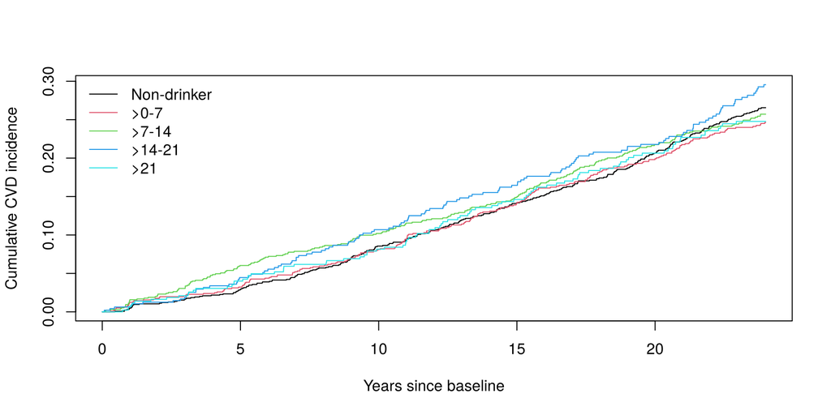

```r
km <- survfit(Surv(t_cvd, e_cvd) ~ alc_cat, data = dc)
plot(km, col = 1:5, fun = "event", xlab = "Years since baseline", ylab = "Cumulative CVD incidence")
legend("topleft", levels(dc$alc_cat), col = 1:5, lty = 1, bty = "n")
```

```r
survdiff(Surv(t_cvd, e_cvd) ~ alc_cat, data = dc)   # log-rank test (unadjusted)
```

```
## Call:
## survdiff(formula = Surv(t_cvd, e_cvd) ~ alc_cat, data = dc)
##
##                        N Observed Expected (O-E)^2/E (O-E)^2/V
## alc_cat=Non-drinker 1251      298    296.6   0.00675   0.00976
## alc_cat=>0-7         967      218    232.1   0.85174   1.12335
## alc_cat=>7-14        956      224    222.7   0.00754   0.00982
## alc_cat=>14-21       477      125    109.0   2.33946   2.63941
## alc_cat=>21          432       95     99.6   0.21449   0.23934
##
##  Chisq= 3.4  on 4 degrees of freedom, p= 0.5
```

# 5 Secondary objective 1: dose-response

Three specifications of alcohol are compared with AIC (lower is better), and a likelihood-ratio test for non-linearity compares the spline with the linear model. A natural cubic spline is used with interior knots at the 25th, 50th and 75th centiles **among drinkers** (≈30% of the sample are at zero, so centiles of the whole sample would put knots on top of each other) and boundary knots at 0 and the 99th centile.

```r
pos <- dc$ALC_DPW[dc$ALC_DPW > 0]
kn  <- quantile(pos, c(.25, .50, .75))
bk  <- c(0, quantile(dc$ALC_DPW, .99))
round(c(kn, bk), 1)
```

```
##  25%  50%  75%       99%
##  5.9  9.7 16.7  0.0 49.4
```

```r
spl_rhs <- function() paste0("ns(ALC_DPW, knots = kn, Boundary.knots = bk) + ", adj2)

dr <- lapply(outcomes$key, function(k) {
  fl <- fits_lin[[k]]; fc <- fits_cat[[k]]; fs <- fit_cox(k, spl_rhs())
  fd <- fit_cox(k, paste("drinker + alc7 +", adj2))   # allows a step at 0 (drinker vs non-drinker)
  data.frame(outcome = outcomes$label[outcomes$key == k],
             AIC_linear = AIC(fl), AIC_categorical = AIC(fc), AIC_spline = AIC(fs),
             AIC_step_plus_linear = AIC(fd),
             p_nonlinear = anova(fl, fs)[2, "Pr(>|Chi|)"])
})
dr <- do.call(rbind, dr)
dr[, 2:5] <- round(dr[, 2:5], 1); dr$p_nonlinear <- signif(dr$p_nonlinear, 3)
knitr::kable(dr)
```

| outcome | AIC_linear | AIC_categorical | AIC_spline | AIC_step_plus_linear | p_nonlinear |
| --- | --- | --- | --- | --- | --- |
| Total CVD | 15038.3 | 15044.5 | 15043.7 | 15039.5 | 0.909 |
| Any CHD | 15832.0 | 15836.2 | 15834.0 | 15832.0 | 0.262 |
| MI or fatal CHD | 9162.4 | 9165.0 | 9165.7 | 9163.4 | 0.428 |
| Angina pectoris | 8685.0 | 8691.8 | 8687.6 | 8686.9 | 0.344 |
| Stroke | 5306.8 | 5312.1 | 5309.7 | 5308.7 | 0.371 |

```r
write.csv(dr, "outputs/dose_response_model_comparison.csv", row.names = FALSE)
```

## 5.1 Figure 1: spline curves (HR relative to non-drinkers)

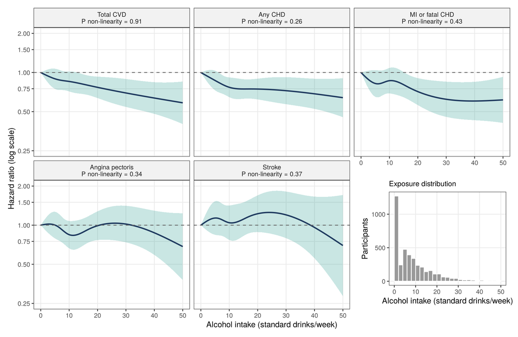

```r
grid_x <- seq(0, 50, by = 0.5)       # displayed range ≈ 0 to 99th centile
spline_curve <- function(k) {
  fs  <- fit_cox(k, spl_rhs())
  X   <- ns(grid_x, knots = kn, Boundary.knots = bk)
  X0  <- ns(0,      knots = kn, Boundary.knots = bk)
  idx <- grep("ns\\(ALC_DPW", names(coef(fs)))
  Xc  <- sweep(X, 2, X0)                         # contrast vs 0 drinks/week
  lp  <- drop(Xc %*% coef(fs)[idx])
  se  <- sqrt(rowSums((Xc %*% vcov(fs)[idx, idx]) * Xc))
  data.frame(outcome = outcomes$label[outcomes$key == k], x = grid_x,
             hr = exp(lp), lo = exp(lp - 1.96 * se), hi = exp(lp + 1.96 * se))
}
curves <- do.call(rbind, lapply(outcomes$key, spline_curve))
curves$outcome <- factor(curves$outcome, levels = outcomes$label)
pnl <- setNames(paste0(dr$outcome, "\nP non-linearity = ", formatC(dr$p_nonlinear, format = "f", digits = 2)),
                dr$outcome)
curves$panel <- factor(pnl[as.character(curves$outcome)], levels = pnl)

navy <- "#1F3A5F"; teal <- "#2A9D8F"
p_curves <- ggplot(curves, aes(x, hr)) +
  geom_ribbon(aes(ymin = lo, ymax = hi), fill = teal, alpha = 0.25) +
  geom_line(colour = navy, linewidth = 0.9) +
  geom_hline(yintercept = 1, linetype = "dashed", colour = "grey40") +
  scale_y_log10(breaks = c(0.25, 0.5, 0.75, 1, 1.5, 2)) +
  coord_cartesian(ylim = c(0.25, 2)) +
  facet_wrap(~panel, nrow = 2) +
  labs(x = "Alcohol intake (standard drinks/week)", y = "Hazard ratio (log scale)") +
  theme_bw(base_size = 11) +
  theme(strip.background = element_rect(fill = "grey95"), panel.grid.minor = element_blank())

p_hist <- ggplot(subset(dc, ALC_DPW <= 50), aes(ALC_DPW)) +
  geom_histogram(binwidth = 2, boundary = 0, fill = "grey60", colour = "white") +
  labs(x = "Alcohol intake (standard drinks/week)", y = "Participants",
       title = "Exposure distribution") +
  theme_bw(base_size = 11) + theme(plot.title = element_text(size = 10),
                                   panel.grid.minor = element_blank())

fig1 <- p_curves + inset_element(p_hist, left = 0.68, bottom = 0.0, right = 1, top = 0.47)
fig1
```

```r
ggsave("outputs/figure1_dose_response.png", fig1, width = 10, height = 6.5, dpi = 300)
```

# 6 Secondary objective 2: mediation by HDL cholesterol

**Choice of mediator.** HDL-C is the best-supported biological mediator of the alcohol-CHD association (alcohol raises HDL-C, which is inversely associated with CHD). Systolic BP was considered but rejected as the main candidate because it was measured at the *same* visit as alcohol (no temporal ordering) and would act in the opposite direction. HDL-C was measured only at exam 3 (~12 years after baseline), so a **landmark design** is used: participants who attended exam 3 free of CVD, with HDL-C measured; follow-up restarts at exam 3. This gives the temporal ordering exposure (baseline) → mediator (exam 3) → outcome (after exam 3).

**Method (Baron & Kenny / difference method).** (a) exposure → mediator: linear regression of HDL-C on alcohol + confounders; (b) mediator → outcome, adjusted for exposure; (c) total effect: Cox model without HDL-C; (d) direct effect: Cox model with HDL-C. Proportion mediated = (β_total − β_direct)/β_total, with a percentile bootstrap 95% CI (1,000 resamples). An exposure-mediator interaction is also tested.

```r
p3 <- subset(raw, PERIOD == 3) |>
  select(RANDID, TIME3 = TIME, HDLC, LDLC, AGE3 = AGE, BMI3 = BMI, CURSMOKE3 = CURSMOKE, CIGPDAY3 = CIGPDAY)
lm_dat <- dc |> select(-HDLC, -LDLC) |>
  inner_join(p3, by = "RANDID") |>
  filter(TIMECVD > TIME3) |>                                # CVD-free at exam 3
  mutate(t_lm = (TIMECVD - TIME3) / 365.25) |>
  filter(!is.na(HDLC))
c(attended_exam3_and_cvd_free = nrow(dc |> select(-HDLC, -LDLC) |> inner_join(p3, by = "RANDID") |> filter(TIMECVD > TIME3)),
  with_HDL = nrow(lm_dat), events = sum(lm_dat$e_cvd))
```

```
## attended_exam3_and_cvd_free                    with_HDL
##                        2841                        2639
##                      events
##                         415
```

```r
med_fit <- function(dat) {
  a   <- lm(HDLC ~ alc7 + AGE + sex + educ_f + cursmoke + cigpday, data = dat)
  tot <- coxph(Surv(t_lm, e_cvd) ~ alc7 + AGE + sex + educ_f + cursmoke + cigpday, data = dat)
  dir <- coxph(Surv(t_lm, e_cvd) ~ alc7 + HDLC + AGE + sex + educ_f + cursmoke + cigpday, data = dat)
  list(a = a, tot = tot, dir = dir)
}
mf <- med_fit(lm_dat)
step_a <- summary(mf$a)$coef["alc7", ]
step_b <- hr_ci(mf$dir, "HDLC")
total  <- hr_ci(mf$tot, "alc7")
direct <- hr_ci(mf$dir, "alc7")
pm     <- (coef(mf$tot)["alc7"] - coef(mf$dir)["alc7"]) / coef(mf$tot)["alc7"]

# exposure-mediator interaction
int_am <- coxph(Surv(t_lm, e_cvd) ~ alc7 * HDLC + AGE + sex + educ_f + cursmoke + cigpday, data = lm_dat)
p_int_am <- anova(mf$dir, int_am)[2, "Pr(>|Chi|)"]

# bootstrap CI for proportion mediated
B <- 1000
boot_pm <- replicate(B, {
  bd <- lm_dat[sample(nrow(lm_dat), replace = TRUE), ]
  f  <- med_fit(bd)
  (coef(f$tot)["alc7"] - coef(f$dir)["alc7"]) / coef(f$tot)["alc7"]
})
pm_ci <- quantile(boot_pm, c(.025, .975))

mediation <- data.frame(
  quantity = c("a: HDL-C (mg/dL) per 7 drinks/week", "b: HR per 1 mg/dL HDL-C",
               "Total effect HR per 7 drinks/week", "Direct effect HR per 7 drinks/week",
               "Proportion mediated (%)", "P exposure x mediator interaction"),
  estimate = c(sprintf("%.2f (%.2f to %.2f); P=%s", step_a[1], step_a[1] - 1.96 * step_a[2],
                       step_a[1] + 1.96 * step_a[2], fmt_p(step_a[4])),
               paste0(sprintf("%.3f (%.3f-%.3f)", step_b[1], step_b[2], step_b[3]), "; P=", fmt_p(step_b[4])),
               paste0(fmt_hr(total), "; P=", fmt_p(total[4])),
               paste0(fmt_hr(direct), "; P=", fmt_p(direct[4])),
               sprintf("%.1f (%.1f to %.1f)", 100 * pm, 100 * pm_ci[1], 100 * pm_ci[2]),
               fmt_p(p_int_am)))
knitr::kable(mediation)
```

| quantity | estimate |
| --- | --- |
| a: HDL-C (mg/dL) per 7 drinks/week | -0.08 (-0.46 to 0.29); P=0.660 |
| b: HR per 1 mg/dL HDL-C | 0.990 (0.983-0.997); P=0.008 |
| Total effect HR per 7 drinks/week | 0.91 (0.85-0.98); P=0.014 |
| Direct effect HR per 7 drinks/week | 0.91 (0.85-0.98); P=0.015 |
| Proportion mediated (%) | 0.5 (-6.2 to 8.8) |
| P exposure x mediator interaction | 0.944 |

```r
write.csv(mediation, "outputs/mediation_hdl.csv", row.names = FALSE)
```

**Alternative mediator (code only): baseline systolic BP**, full cohort, same difference method.

```r
sbp_a  <- summary(lm(SYSBP ~ alc7 + AGE + sex + educ_f + cursmoke + cigpday, data = dc))$coef["alc7", ]
sbp_t  <- fits_lin$cvd
sbp_d  <- coxph(Surv(t_cvd, e_cvd) ~ alc7 + SYSBP + AGE + sex + educ_f + cursmoke + cigpday, data = dc)
round(c(a_coef = sbp_a[1], a_p = sbp_a[4],
        HR_total = exp(coef(sbp_t)["alc7"]), HR_direct = exp(coef(sbp_d)["alc7"]),
        prop_mediated = (coef(sbp_t)["alc7"] - coef(sbp_d)["alc7"]) / coef(sbp_t)["alc7"]), 3)
```

```
##    a_coef.Estimate       a_p.Pr(>|t|)      HR_total.alc7     HR_direct.alc7
##              0.300              0.159              0.925              0.917
## prop_mediated.alc7
##             -0.108
```

# 7 Secondary objective 3: effect modification by sex

Sex is the pre-specified modifier: women reach higher blood-alcohol concentrations per drink and have different baseline CVD risk, and guidelines set sex-specific drinking limits. Multiplicative interaction is tested with a likelihood-ratio test (alcohol × sex product term); sex-specific HRs are reported (subgroup analyses). Current smoking is examined as a secondary modifier (code only).

```r
em_rows <- list()
for (k in outcomes$key) {
  base_m <- fit_cox(k, paste("alc7 +", adj2))
  int_m  <- fit_cox(k, paste("alc7 * sex +", adj2))
  p_int  <- anova(base_m, int_m)[2, "Pr(>|Chi|)"]
  hr_m <- hr_ci(fit_cox(k, "alc7 + AGE + educ_f + cursmoke + cigpday", data = subset(dc, sex == "Men")), "alc7")
  hr_w <- hr_ci(fit_cox(k, "alc7 + AGE + educ_f + cursmoke + cigpday", data = subset(dc, sex == "Women")), "alc7")
  em_rows[[k]] <- data.frame(outcome = outcomes$label[outcomes$key == k],
                             HR_men = fmt_hr(hr_m), HR_women = fmt_hr(hr_w), P_interaction = fmt_p(p_int),
                             m_hr = hr_m[1], m_lo = hr_m[2], m_hi = hr_m[3],
                             w_hr = hr_w[1], w_lo = hr_w[2], w_hi = hr_w[3], p_int = p_int)
}
em <- do.call(rbind, em_rows); rownames(em) <- NULL
knitr::kable(em[, 1:4])
```

| outcome | HR_men | HR_women | P_interaction |
| --- | --- | --- | --- |
| Total CVD | 0.93 (0.89-0.98) | 0.89 (0.80-0.99) | 0.371 |
| Any CHD | 0.94 (0.89-0.99) | 0.90 (0.81-0.99) | 0.304 |
| MI or fatal CHD | 0.95 (0.89-1.01) | 0.80 (0.68-0.95) | 0.045 |
| Angina pectoris | 0.96 (0.89-1.03) | 0.97 (0.86-1.09) | 0.792 |
| Stroke | 1.01 (0.93-1.11) | 0.97 (0.84-1.12) | 0.715 |

```r
write.csv(em, "outputs/effect_modification_sex.csv", row.names = FALSE)

# categorical HRs by sex (CVD)
by_sex_cat <- sapply(c("Men", "Women"), function(s) {
  f <- fit_cox("cvd", "alc_cat + AGE + educ_f + cursmoke + cigpday", data = subset(dc, sex == s))
  sapply(levels(dc$alc_cat)[-1], function(j) fmt_hr(hr_ci(f, paste0("alc_cat", j))))
})
by_sex_cat
```

```
##        Men                Women
## >0-7   "0.97 (0.74-1.26)" "0.84 (0.66-1.07)"
## >7-14  "0.87 (0.68-1.13)" "0.86 (0.66-1.13)"
## >14-21 "0.88 (0.67-1.17)" "0.75 (0.49-1.16)"
## >21    "0.71 (0.53-0.95)" "0.59 (0.32-1.09)"
```

```r
p_int_cat <- anova(fit_cox("cvd", paste("alc_cat +", adj2)),
                   fit_cox("cvd", paste("alc_cat * sex +", adj2)))[2, "Pr(>|Chi|)"]
p_int_cat
```

```
## [1] 0.9123663
```

```r
# secondary modifier: current smoking (code only)
anova(fit_cox("cvd", paste("alc7 +", adj2)), fit_cox("cvd", paste("alc7 * cursmoke +", adj2)))
```

```
## Analysis of Deviance Table
##  Cox model: response is  Surv(t_cvd, e_cvd)
##  Model 1: ~ alc7 + AGE + sex + educ_f + cursmoke + cigpday
##  Model 2: ~ alc7 * cursmoke + AGE + sex + educ_f + cursmoke + cigpday
##    loglik  Chisq Df Pr(>|Chi|)
## 1 -7511.1
## 2 -7511.0 0.2458  1     0.6201
```

# 8 Sensitivity analyses

All for the primary outcome (total CVD), HR per 7 drinks/week, Model 2 unless stated.

```r
sens <- list()
sens[["Primary analysis (complete cases)"]] <- hr_ci(fits_lin$cvd, "alc7")

# S1. reverse causation: exclude the first 2 years of follow-up (delayed entry at 2 years)
s1 <- coxph(Surv(rep(2, sum(dc$t_cvd > 2)), t_cvd, e_cvd) ~ alc7 + AGE + sex + educ_f + cursmoke + cigpday,
            data = subset(dc, t_cvd > 2))
sens[["Exclude first 2 years of follow-up"]] <- hr_ci(s1, "alc7")

# S2. follow-up period: censor at 12 years (alcohol measured once, so later exposure is less certain)
dc12 <- dc |> mutate(e12 = ifelse(t_cvd > 12, 0, e_cvd), t12 = pmin(t_cvd, 12))
s2 <- coxph(Surv(t12, e12) ~ alc7 + AGE + sex + educ_f + cursmoke + cigpday, data = dc12)
sens[["Follow-up truncated at 12 years"]] <- hr_ci(s2, "alc7")

# S3. 'sick quitter' bias: drinkers only (removes non-drinkers, who may include former drinkers)
s3 <- fit_cox("cvd", paste("alc7 +", adj2), data = subset(dc, ALC_DPW > 0))
sens[["Drinkers only"]] <- hr_ci(s3, "alc7")

# S4. further adjustment for BMI, total cholesterol and diabetes (could confound or mediate)
s4 <- fit_cox("cvd", paste("alc7 +", adj2, "+ BMI + TOTCHOL + DIABETES"))
sens[["+ BMI, cholesterol, diabetes"]] <- hr_ci(s4, "alc7")

# S5. baseline hazard stratified by 5-year age band (PH check above)
sens[["Baseline hazard stratified by age band"]] <- hr_ci(fit_strat, "alc7")

# S6. excluding extreme intakes (> 99th centile, 'outliers' kept in primary analysis)
s6 <- fit_cox("cvd", paste("alc7 +", adj2), data = subset(dc, ALC_DPW <= quantile(dc$ALC_DPW, .99)))
sens[["Exclude intake > 99th centile"]] <- hr_ci(s6, "alc7")
```

## 8.1 S7. Multiple imputation of missing covariates

Missing covariates (education, cigarettes/day, BMI, cholesterol, BP medication, glucose, heart rate) are imputed by chained equations (predictive mean matching for continuous, polytomous/logistic regression for categorical), m = 20. The imputation model includes the exposure, all confounders, auxiliary variables, the CVD event indicator and the Nelson-Aalen cumulative hazard (White & Royston 2009), so it is compatible with the Cox analysis model. Results are pooled with Rubin’s rules.

```r
mi_dat <- d |>
  mutate(H_cvd = nelsonaalen(d, t_cvd, e_cvd), cursmoke = factor(cursmoke),
         DIABETES = factor(DIABETES), BPMEDS = factor(BPMEDS)) |>
  select(AGE, sex, educ_f, cursmoke, cigpday, alc7, BMI, TOTCHOL, SYSBP, DIABP, DIABETES, BPMEDS,
         GLUCOSE, HEARTRTE, e_cvd, t_cvd, H_cvd)
meth <- make.method(mi_dat)
meth[c("educ_f")] <- "polyreg"
pred <- make.predictorMatrix(mi_dat); pred[, "t_cvd"] <- 0      # use H_cvd instead of raw time
imp <- mice(mi_dat, m = 20, method = meth, predictorMatrix = pred, printFlag = FALSE)
mi_fit <- with(imp, coxph(Surv(t_cvd, e_cvd) ~ alc7 + AGE + sex + educ_f + cursmoke + cigpday))
mi_pool <- summary(pool(mi_fit), conf.int = TRUE)
mi_pool
```

```
##                    term     estimate   std.error   statistic       df
## 1                  alc7 -0.070307938 0.023275796  -3.0206459 985.8710
## 2                   AGE  0.070670009 0.004022059  17.5706050 985.2550
## 3              sexWomen -0.787540507 0.071317035 -11.0428106 984.9972
## 4 educ_fHigh school/GED -0.029097281 0.077903456  -0.3735044 950.8479
## 5    educ_fSome college -0.291491520 0.102623768  -2.8403900 944.8138
## 6  educ_fCollege degree -0.165536952 0.108969935  -1.5191066 904.2002
## 7             cursmoke1  0.160363781 0.098803778   1.6230531 978.8647
## 8               cigpday  0.007576175 0.003983665   1.9018104 968.9609
##        p.value         2.5 %      97.5 %
## 1 2.587402e-03 -0.1159837360 -0.02463214
## 2 2.499992e-60  0.0627772222  0.07856280
## 3 8.244032e-27 -0.9274912953 -0.64758972
## 4 7.088564e-01 -0.1819798533  0.12378529
## 5 4.602619e-03 -0.4928884050 -0.09009464
## 6 1.290852e-01 -0.3794003707  0.04832647
## 7 1.049000e-01 -0.0335278067  0.35425537
## 8 5.749231e-02 -0.0002414296  0.01539378
```

```r
r <- mi_pool[mi_pool$term == "alc7", ]
sens[["Multiple imputation (n = 4,215)"]] <- c(HR = exp(r$estimate), lo = exp(r$`2.5 %`),
                                               hi = exp(r$`97.5 %`), p = r$p.value)
```

```r
sens_tab <- data.frame(analysis = names(sens), do.call(rbind, sens), row.names = NULL)
names(sens_tab)[2:5] <- c("HR", "lo", "hi", "p")
sens_tab$HR_95CI <- apply(sens_tab[, 2:4], 1, fmt_hr)
knitr::kable(sens_tab[, c("analysis", "HR_95CI", "p")])
```

| analysis | HR_95CI | p |
| --- | --- | --- |
| Primary analysis (complete cases) | 0.92 (0.88-0.97) | 0.0010863 |
| Exclude first 2 years of follow-up | 0.92 (0.87-0.96) | 0.0005971 |
| Follow-up truncated at 12 years | 0.94 (0.88-1.01) | 0.0837193 |
| Drinkers only | 0.94 (0.89-0.99) | 0.0171342 |
| + BMI, cholesterol, diabetes | 0.92 (0.88-0.97) | 0.0007412 |
| Baseline hazard stratified by age band | 0.92 (0.88-0.97) | 0.0010721 |
| Exclude intake > 99th centile | 0.92 (0.87-0.97) | 0.0020021 |
| Multiple imputation (n = 4,215) | 0.93 (0.89-0.98) | 0.0025874 |

```r
write.csv(sens_tab, "outputs/sensitivity_analyses.csv", row.names = FALSE)
```

# 9 Figure 2: robustness, effect modification and mediation (total CVD)

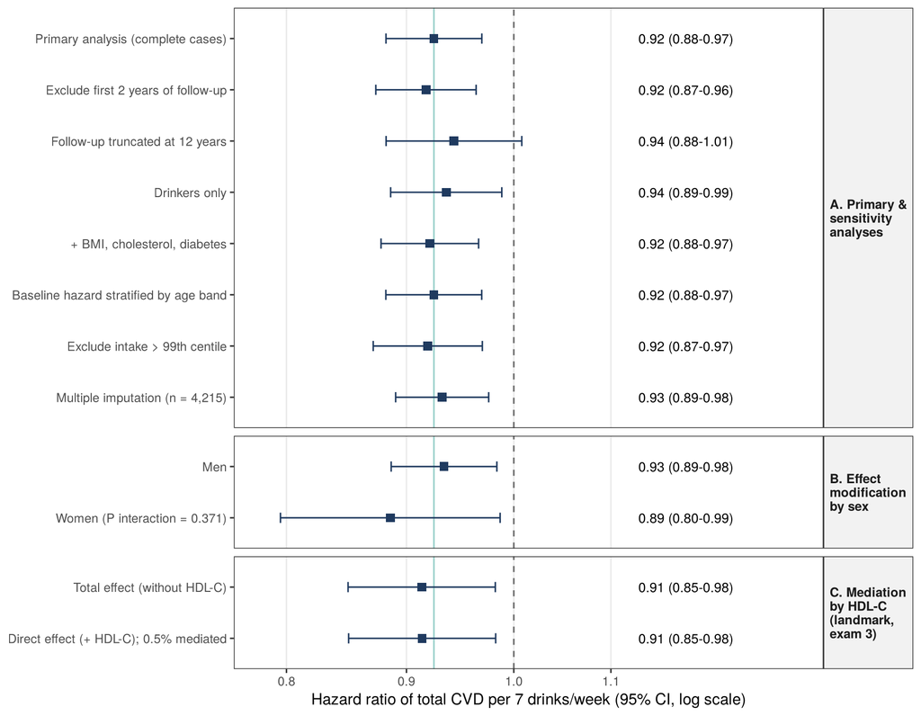

```r
em_cvd <- subset(em, outcome == "Total CVD")
f2 <- rbind(
  data.frame(section = "A. Primary &\nsensitivity\nanalyses", label = sens_tab$analysis,
             HR = sens_tab$HR, lo = sens_tab$lo, hi = sens_tab$hi),
  data.frame(section = "B. Effect\nmodification\nby sex",
             label = c("Men", paste0("Women (P interaction = ", fmt_p(em_cvd$p_int), ")")),
             HR = c(em_cvd$m_hr, em_cvd$w_hr), lo = c(em_cvd$m_lo, em_cvd$w_lo),
             hi = c(em_cvd$m_hi, em_cvd$w_hi)),
  data.frame(section = "C. Mediation\nby HDL-C\n(landmark,\nexam 3)",
             label = c("Total effect (without HDL-C)",
                       sprintf("Direct effect (+ HDL-C); %.1f%% mediated", 100 * pm)),
             HR = c(total[1], direct[1]), lo = c(total[2], direct[2]), hi = c(total[3], direct[3])))
f2$label <- factor(f2$label, levels = rev(unique(f2$label)))
f2$txt <- sprintf("%.2f (%.2f-%.2f)", f2$HR, f2$lo, f2$hi)

fig2 <- ggplot(f2, aes(HR, label)) +
  geom_vline(xintercept = 1, linetype = "dashed", colour = "grey40") +
  geom_vline(xintercept = sens_tab$HR[1], colour = teal, alpha = 0.5) +
  geom_errorbarh(aes(xmin = lo, xmax = hi), height = 0.2, colour = navy) +
  geom_point(shape = 15, size = 2.6, colour = navy) +
  geom_text(aes(x = 1.13, label = txt), hjust = 0, size = 3.3) +
  facet_grid(section ~ ., scales = "free_y", space = "free_y") +
  scale_x_log10(breaks = c(0.8, 0.9, 1.0, 1.1)) +
  coord_cartesian(xlim = c(0.78, 1.32)) +
  labs(x = "Hazard ratio of total CVD per 7 drinks/week (95% CI, log scale)", y = NULL) +
  theme_bw(base_size = 11) +
  theme(strip.text.y = element_text(angle = 0, hjust = 0, face = "bold", size = 9),
        strip.background = element_rect(fill = "grey95"), panel.grid.minor = element_blank(),
        panel.grid.major.y = element_blank())
fig2
```

```r
ggsave("outputs/figure2_forest.png", fig2, width = 8.5, height = 6, dpi = 300)
```

# 10 Numbers quoted in the report

```r
key <- list(
  n_cohort = nrow(d), n_cc = nrow(dc), events_cvd = sum(dc$e_cvd),
  median_fu = median(dc$t_cvd), person_years = sum(dc$t_cvd),
  pct_nondrinkers = 100 * mean(d$ALC_DPW == 0),
  median_alc_drinkers = median(d$ALC_DPW[d$ALC_DPW > 0]),
  hr_cvd_per7 = hr_ci(fits_lin$cvd, "alc7"),
  ph_table = ph_tab, dose_response = dr,
  landmark_n = nrow(lm_dat), landmark_events = sum(lm_dat$e_cvd),
  prop_mediated = c(pm, pm_ci)
)
str(key)
```

```
## List of 13
##  $ n_cohort           : int 4215
##  $ n_cc               : int 4083
##  $ events_cvd         : int 960
##  $ median_fu          : num 24
##  $ person_years       : num 79198
##  $ pct_nondrinkers    : num 30.5
##  $ median_alc_drinkers: num 9.7
##  $ hr_cvd_per7        : Named num [1:4] 0.92458 0.8821 0.96911 0.00109
##   ..- attr(*, "names")= chr [1:4] "HR" "lo" "hi" "p"
##  $ ph_table           : num [1:5, 1:2] 0.227 0.758 0.356 0.948 0.89 ...
##   ..- attr(*, "dimnames")=List of 2
##   .. ..$ : chr [1:5] "Total CVD" "Any CHD" "MI or fatal CHD" "Angina pectoris" ...
##   .. ..$ : chr [1:2] "alcohol_p" "global_p"
##  $ dose_response      :'data.frame': 5 obs. of  6 variables:
##   ..$ outcome             : chr [1:5] "Total CVD" "Any CHD" "MI or fatal CHD" "Angina pectoris" ...
##   ..$ AIC_linear          : num [1:5] 15038 15832 9162 8685 5307
##   ..$ AIC_categorical     : num [1:5] 15044 15836 9165 8692 5312
##   ..$ AIC_spline          : num [1:5] 15044 15834 9166 8688 5310
##   ..$ AIC_step_plus_linear: num [1:5] 15040 15832 9163 8687 5309
##   ..$ p_nonlinear         : num [1:5] 0.909 0.262 0.428 0.344 0.371
##  $ landmark_n         : int 2639
##  $ landmark_events    : int 415
##  $ prop_mediated      : Named num [1:3] 0.00505 -0.06202 0.08838
##   ..- attr(*, "names")= chr [1:3] "alc7" "2.5%" "97.5%"
```

```r
saveRDS(key, "outputs/key_numbers.rds")
```